# Reproducible Research: Peer Assessment 1

## Pre

We will need the lattice package for the last question, so we load it at the start

```r
library(lattice)
```

## 1. Loading and preprocessing the data

### 1.1. Load data

```r
if (!file.exists("activity.csv")) {
  if (!file.exists("activity.zip")) {
    dlurl <- 'http://d396qusza40orc.cloudfront.net/repdata%2Fdata%2Factivity.zip'
    download.file(dlurl,destfile='activity.zip',mode='wb')
  }
  unzip('activity.zip')
}
data <- read.csv("activity.csv")
```

### 1.2. Process/transform the data (if necessary) into a format suitable for your analysis.

There is no need to process/transform the data.

## 2. What is mean total number of steps taken per day?

### 2.1. Calculate the total number of steps taken per day and print the output.

```r
steps_by_day <- aggregate(steps ~ date, data, sum)
head(steps_by_day)
```

```
##         date steps
## 1 2012-10-02   126
## 2 2012-10-03 11352
## 3 2012-10-04 12116
## 4 2012-10-05 13294
## 5 2012-10-06 15420
## 6 2012-10-07 11015
```

### 2.2. If you do not understand the difference between a histogram and a barplot, research the difference between them. Make a histogram of the total number of steps taken each day

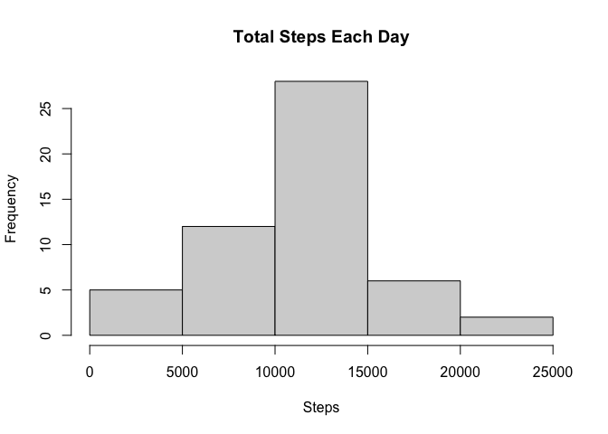

```r
hist(steps_by_day$steps, main = paste("Total Steps Each Day"),xlab="Steps")
```

### 2.3. Calculate and report the mean and median of the total number of steps taken per day.

```r
steps_mean <- mean(steps_by_day$steps)
steps_mean
```

```
## [1] 10766.19
```

```r
steps_median <- median(steps_by_day$steps)
steps_median
```

```
## [1] 10765
```

## What is the average daily activity pattern?

### 3.1. Make a time series plot (i.e. type = “l”) of the 5-minute interval (x-axis) and the average number of steps taken, averaged across all days (y-axis)

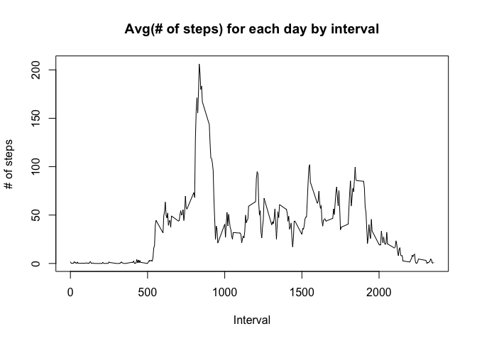

```r
steps_by_interval <- aggregate(steps ~ interval, data, mean)
plot(steps_by_interval$interval,
     steps_by_interval$steps,
     type="l",
     xlab="Interval",
     ylab="# of steps",
     main="Avg(# of steps) for each day by interval")
```

### 3.2. Which 5-minute interval, on average across all the days in the dataset, contains the maximum number of steps?

```r
max_interval <- steps_by_interval[which.max(steps_by_interval$steps),1]
max_interval
```

```
## [1] 835
```

## Imputing missing values

Note that there are a number of days/intervals where there are missing values (coded as NA).The presence of missing days may introduce bias into some calculations or summaries of the data.

### 4.1. Calculate and report the total number of missing values in the dataset

(i.e. the total number of rows with NAs)

```r
NATotal <- sum(!complete.cases(data))
NATotal
```

```
## [1] 2304
```

### 4.2. Devise a strategy for filling in all of the missing values in the dataset.

The strategy does not need to be sophisticated. For example, you could use the mean/median for that day, or the mean for that 5-minute interval, etc.

```r
avg_steps <- aggregate(steps ~ interval, data = data, FUN = mean)
fillNA <- numeric()
for (i in 1:nrow(data)) {
  obs <- data[i, ]
  if (is.na(obs$steps)) {
    steps <- subset(avg_steps, interval == obs$interval)$steps
  } else {
    steps <- obs$steps
  }
  fillNA <- c(fillNA, steps)
}
```

### 4.3. Create a new dataset that is equal to the original dataset but with the missing data filled in.

```r
new_activity <- data
new_activity$steps <- fillNA
summary(new_activity)
```

```
##      steps            date              interval
##  Min.   :  0.00   Length:17568       Min.   :   0.0
##  1st Qu.:  0.00   Class :character   1st Qu.: 588.8
##  Median :  0.00   Mode  :character   Median :1177.5
##  Mean   : 37.38                      Mean   :1177.5
##  3rd Qu.: 27.00                      3rd Qu.:1766.2
##  Max.   :806.00                      Max.   :2355.0
```

### 4.4. Make a histogram of the total number of steps taken each day

and Calculate and report the mean and median total number of steps taken per day. Do these values differ from the estimates from the first part of the assignment? What is the impact of imputing missing data on the estimates of the total daily number of steps?

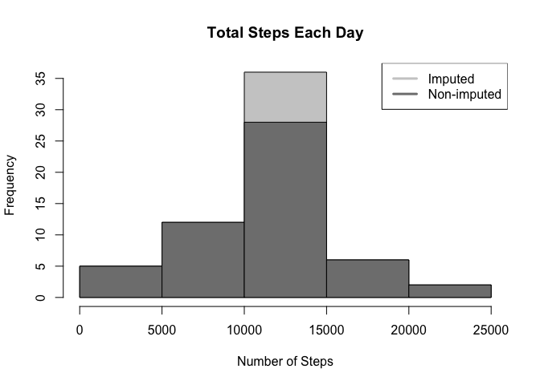

```r
StepsTotalUnion <- aggregate(steps ~ date, data = new_activity, sum, na.rm = TRUE)
hist(StepsTotalUnion$steps,
     main = paste("Total Steps Each Day"),
     col="gray80",
     xlab="Number of Steps")
# Create histogram to show difference
hist(steps_by_day$steps,
     main = paste("Total Steps Each Day"),
     col="gray50",
     xlab="Number of Steps",
     add=T)
legend("topright",
       c("Imputed", "Non-imputed"),
       col=c("gray80", "gray50"),
       lwd=3)
```

Calculate and report the mean and median total number of steps taken per day

```r
steps_mean_total <- mean(StepsTotalUnion$steps)
steps_mean_total
```

```
## [1] 10766.19
```

```r
steps_median_total <- median(StepsTotalUnion$steps)
steps_median_total
```

```
## [1] 10766.19
```

Do these values differ from the estimates from the first part of the assignment?

```r
steps_median_diff <- steps_median_total - steps_median
steps_median_diff
```

```
## [1] 1.188679
```

```r
steps_mean_diff <- steps_mean_total - steps_mean
steps_mean_diff
```

```
## [1] 0
```

## Are there differences in activity patterns between weekdays and weekends?

### 5.1. Create a new factor variable in the dataset with two levels – “weekday” and “weekend” indicating whether a given date is a weekday or weekend day.

```r
weekdays <- c("Monday", "Tuesday", "Wednesday", "Thursday", "Friday")
new_activity$dow = as.factor(ifelse(is.element(weekdays(as.Date(new_activity$date)),weekdays), "Weekday", "Weekend"))
StepsTotalUnion <- aggregate(steps ~ interval + dow, new_activity, mean)
```

### 5.2 Make a panel plot containing a time series plot (i.e. type = “l”) of the 5-minute interval (x-axis) and the average number of steps taken, averaged across all weekday days or weekend days (y-axis).

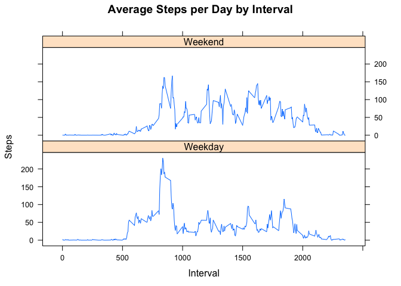

```r
xyplot(StepsTotalUnion$steps ~ StepsTotalUnion$interval|StepsTotalUnion$dow,
       main="Average Steps per Day by Interval",
       xlab="Interval",
       ylab="Steps",
       layout=c(1,2),
       type="l")
```